# Case_Study_Bike_Share

Pedro Mesquita

2022-05-10

# Intro

In the final step to finish my Google Data Analytics Certificate, I was introduced to resolve an optional case study to display and to put to the test my new learned skills. I’m happy that I opted to do it because technical skills can get more understood and developed when I put them into practice.

Scenario: in the provided prompt, I’m a data analyst working at Cyclistic (fictitious bike-sharing company). The company wants to design a new marketing strategy with the goal of converting casual riders into annual members. But first, they want to know how casual riders and annual members use bikes differently.

As learned in this course, I will explore this case study with the 6 phases of data analysis (Ask, Prepare, Process, Analyze, Share and Act.

# PHASE 1 - ASK

The finance department at Cyclistic has determined that annual members are the more profitable customer type and are trying to create a campaign aimed at converting casual riders to annual members. To help them complete this business task, the finance team has assigned me with answering the following question: “How do annual members and casual riders use Cyclistic bikes differently?”

# PHASE 2 - PREPARE and PHASE 3 - PROCESS

To answer the question asked, I will store the historical bike trip data from the company, which is in 12 csv files corresponding to 12 months of the year 2021.

But is this a good data source? Let’s find out if it meets the following criteria: * Reliable: it’s accurate, complete, and unbiased, because every bike trip was registered in the source files and so this reflects the overall population of users. * Original: the original data source was found * Comprehensive: there is no missing information in the data to answer the question * Current: the data used in this project is recent and it is updated regularly (every month) * Cited: this source has been cited by other students of Google Data Analytics

There are some key facts or constraints about the data: * Each month contains every single trip that has occurred * There is no customer information, in order to respect the privacy of the users * The data should have no trips shorter than 1 minute or longer than 1 day. Any data that does not fit these constraints should be removed as it is a maintenance trip carried out by the Cyclistic team, or the bike has been stolen.

Note: The dataset used in this project can be found [here](https://divvy-tripdata.s3.amazonaws.com/index.html). This data is anonymized to ensure privacy, but it limits the extent of the analysis possible. The data is released under this [license](https://ride.divvybikes.com/data-license-agreement).

## Load Packages

```r
library(tidyverse)
library(lubridate)
library(janitor)
library(dplyr)
library(scales)
```

```r
library(mapview)
```

## Load the Data

Loading all the csv files (12) in the folder and assigning them to a data frame.

```r
original_df <- dir("01_Sources", full.name =T) %>%
  map_df(read_csv)
df <- original_df
```

## Transform the Data

### Creating new columns

Calculating the ride length of each ride and turning it into a numeric value.

```r
df <- mutate(df, ride_length = ended_at - started_at)
df$ride_length <- as.numeric(as.character(df$ride_length))
```

Adding columns that list date, year, month, day, day of the week and time started of each ride. This will allow us to aggregate ride data for each month, day, or year … before completing these operations we could only aggregate at the ride level.

```r
df$date <- as.Date(df$started_at)
df$year <- format(as.Date(df$started_at), "%Y")
df$month <- format(as.Date(df$started_at), "%m")
df$day <- format(as.Date(df$started_at), "%d")
df$day_of_week <- format(as.Date(df$started_at), "%A")
df$time <- format(df$started_at, format= "%H:%M")
```

## Clean the Data

### Filtering irrelevant data

In this analysis I will NOT consider the following criteria: * trips that took less than a 60 seconds, as it is probably a maintenance; * trips that took more than a day (86400 sec), as I consider this as a stolen bike.

```r
df <- filter(df, ride_length > 60)
df <- filter(df, ride_length < 86400)
```

## Filtering Outliers

### Calculating the Z-Score

Calculating the mean, standard deviation and zscore. And adding the zscore in a new column.

```r
df_mean <- mean(df$ride_length)
df_sd <- sd(df$ride_length)
df_zscore <- (df$ride_length-mean(df$ride_length))/sd(df$ride_length)
df <- data.frame(df, df_zscore)
```

Filtering the data frame with data points that have a zscore less than 3 and removing the zscore column from the data frame.

```r
df <- df[!(df_zscore > 3), ]
df <- subset(df, select = -c(df_zscore))
```

## Renaming columns

Renaming some columns to make the data more readable.

```r
df <- df %>%
  rename(trip_id = ride_id, ride_type = rideable_type, user_type = member_casual)
```

# PHASE 4 - ANALYZE

## View the Data

### Data Viz 1 - Number of rides by user type and week day

Ordering the days of the week and creating the first data viz

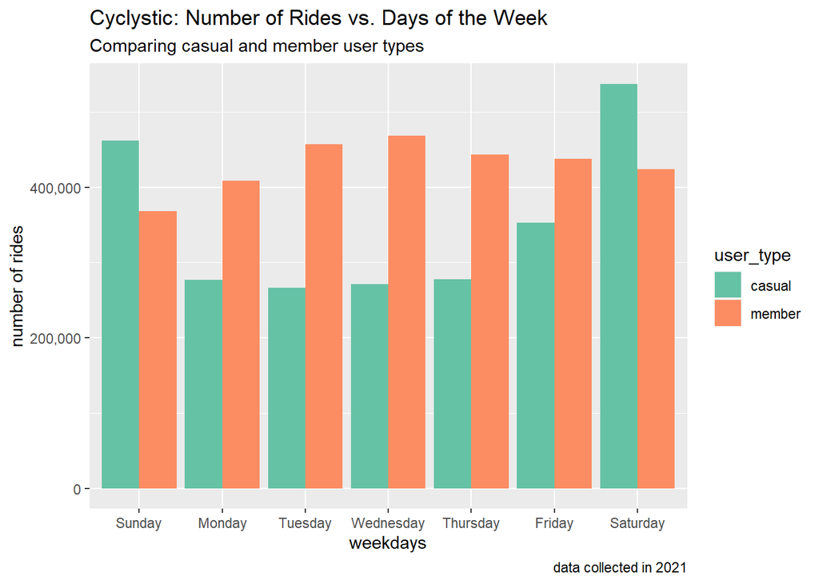

```r
df$day_of_week <- ordered(df$day_of_week, levels=c("Sunday", "Monday", "Tuesday", "Wednesday", "Thursday", "Friday", "Saturday"))

df %>%
  group_by(user_type, day_of_week) %>%
  summarise(number_of_rides = n()
            ,average_duration = mean(ride_length)) %>%
  arrange(user_type, day_of_week)  %>%
  ggplot(aes(x = day_of_week, y = number_of_rides, fill = user_type)) +
  geom_col(position = "dodge") +
  xlab('weekdays') +
  ylab('number of rides') +
  scale_y_continuous(labels = scales::comma) +
  labs(title="Cyclystic: Number of Rides vs. Days of the Week", subtitle = "Comparing casual and member user types", caption="data collected in 2021") +
  scale_fill_brewer(palette = "Set2")
```

### Data Viz 2 - Average ride duration by user type and week day

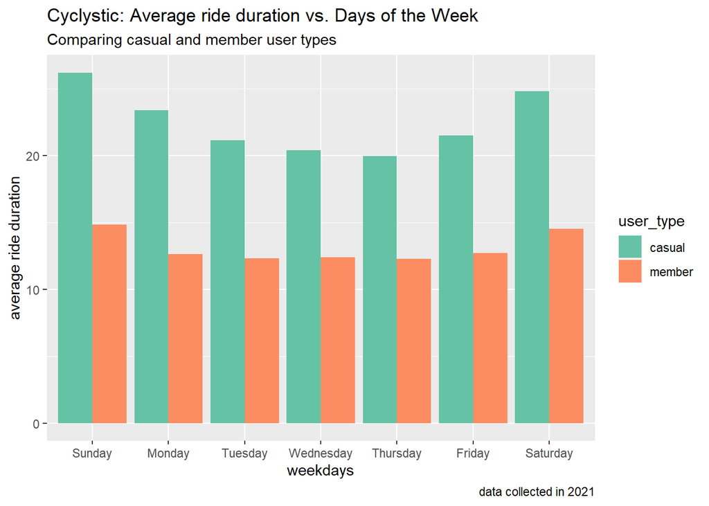

```r
df %>%
  group_by(user_type, day_of_week) %>%
  summarise(number_of_rides = n()
            ,average_duration = mean(ride_length/60)) %>%
  arrange(user_type, day_of_week)  %>%
  ggplot(aes(x = day_of_week, y = average_duration, fill = user_type)) +
  geom_col(position = "dodge")+
  xlab('weekdays') +
  ylab('average ride duration') +
  labs(title="Cyclystic: Average ride duration vs. Days of the Week", subtitle = "Comparing casual and member user types", caption="data collected in 2021") +
  scale_fill_brewer(palette = "Set2")
```

### Data Viz 3 - Number of rides by user type and month

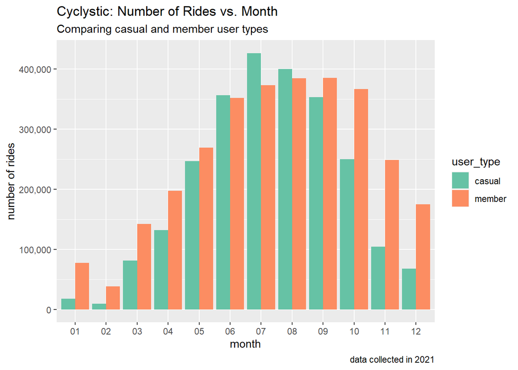

```r
df$month <- ordered(df$month, levels=c("01", "02", "03", "04", "05", "06", "07", "08", "09", "10", "11", "12"))

df %>%
  group_by(user_type, month) %>%
  summarise(number_of_rides = n()
            ,average_duration = mean(ride_length)) %>%
  arrange(user_type, month)  %>%
  ggplot(aes(x = month, y = number_of_rides, fill = user_type)) +
  geom_col(position = "dodge") +
  xlab('month') +
  ylab('number of rides') +
  scale_y_continuous(labels = scales::comma) +
  labs(title="Cyclystic: Number of Rides vs. Month", subtitle = "Comparing casual and member user types", caption="data collected in 2021") +
  scale_fill_brewer(palette = "Set2")
```

# PHASE 5 - SHARE

In this script is presented all the analysis that took place.

# PHASE 6 - ACT

### Key Takeways

- Casual riders travel more during the weekends, while annual members use them consistently over the entire week.
- Casual riders have a trip duration almost twice greater than the annual members.
- There is a significant usage of bike services in the summer by both user types

### Recomendations

Based on the analysis of the data, the following recommendations can be made to the Cyclistic stakeholders:

- To convert casual riders into annual members, marketing campaigns should be targeted towards weekends (since the greatest number of rides by casual riders happens in those days) or summer months (since it is when the greatest number of rides happen).
- It is important to convert casual riders into annual members since they have the most average ride duration.
- Further analysis should be done to determine which casual riders are live in Chicago, as these riders are more likely to consider obtaining an annual membership compared to a tourist.